# **Funciones exponencial y logarítmica**

John J Estrada

2020-07-28

# Concepto de función

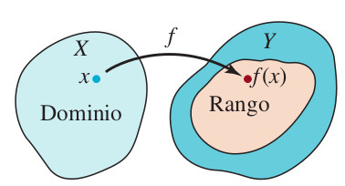

Concepto de función real [Imagen tomada de (Zill & Dewar, 2012) pág $200$]

Una función es una relación especial entre dos conjuntos $A=D_{f}$ y $B=R_{f}$, donde a todo elemento $x$ del conjunto $A$ le corresponde uno y sólo un elemento $y$ del conjuto $B$. Cuando esta relación cumple la propiedad enunciada, diremos que la relación es una función. Es bueno recordar que no toda relación es función.

La siguiente gráfica deja ver la relación entre dos conjuntos en el plano $XY$, donde se muestra que cada punto de la gráfica es una pareja ordenada $(x_i,f(x_i))$.

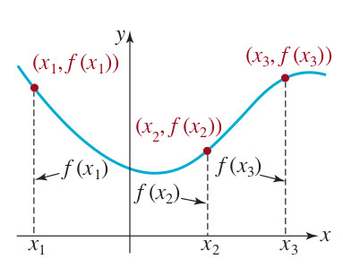

Correspondencia entre cada valor $x$ y $y$ [Imagen tomada de (Zill & Dewar, 2012) pág $202$]

**NOTA**: Si los conjuntos $A$ y $B$ son subconjuntos del conjunto de los números reales, diremos que la función es de variable real. Al cojunto $A=D_{f}$ le llamaremos **dominio** de la función $f$, al conjunot $B=R_{f}$ le llamaremos **rando** de la función.

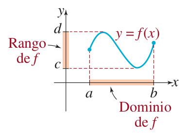

Concepto de dominio y rango para una función de variable real [Imagen tomada de (Zill & Dewar, 2012) pág $203$]

## Ejemplos

[Link primer ejemplo dominio y rango exponencial](https://johnclasesuces.shinyapps.io/DominioYRango1/)

[Link segundo ejemplo dominio y rango exponencial](https://johnclasesuces.shinyapps.io/DominioYRangoPorTramos1/)

Existe un **criterio gráfico** que se usa para determinar si una relación desde su gráfica representa una función, este criterio se llama **criterio de la recta vertical**.

En el siguiente link se puede ejemplificar el uso de este criterio. Haga clic en el link adjunto para poder ver dichos ejemplos.

## Criterio de la recta vertical

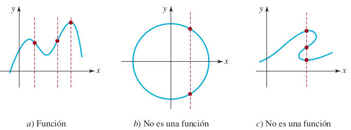

Criterio de la recta vertical [Imagen tomada de (Zill & Dewar, 2012) pág $203$]

[Link para aplicar el criterio de la recta vertical](https://johnclasesuces.shinyapps.io/ConceptoFuncionGrafica1/)

## Desplazamiento horizontal y vertical de una gráfica en el plano $XY$

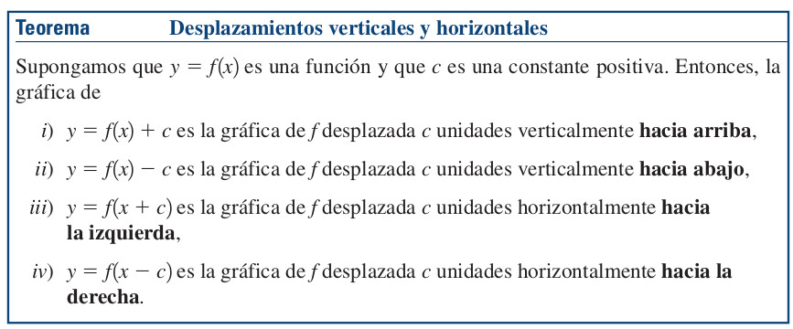

Teorema para la traslación de una función [Imagen tomada de (Zill & Dewar, 2012) pág $211$]

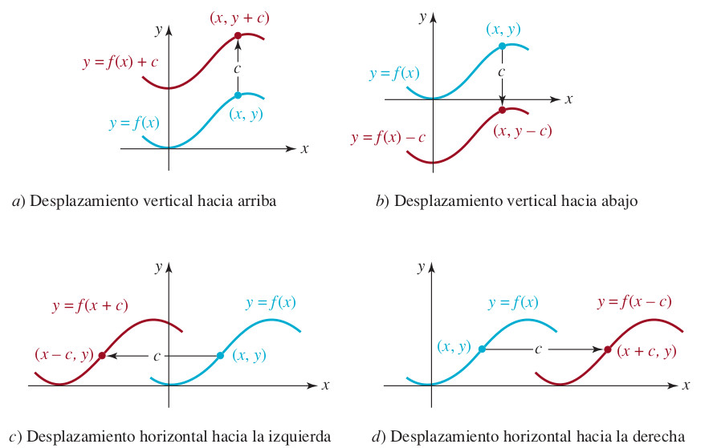

Ejemplo Teorema para la traslación de una función [Imagen tomada de (Zill & Dewar, 2012) pág $212$]